# Monty Hall Problem Model

Dan Conroy-Beam

2024-08-27

## Model Overview

### Purpose

Compare strategies within the Monty Hall Problem. Agents will take turns playing the guessing game from the Monty Hall problem.

The model will determine and store how the agent would have fared in each iteration had they used a stay or a switch strategy.

### Agents

Each iteration of the model will generate a single agent who will play one round of the guessing game from Let’s Make a Deal.

The agent will use, in parallel, both a stay and switch strategy in each round.

### Life Cycle

1. Setup
2. Guess
3. Reveal Goat
4. Stay/Switch
5. Reveal Car

#### Setup

At the start of the life cycle, “Monty Hall” will place a car behind one randomly selected door and goats behind the remaining doors.

#### Guess

During this stage, the agent will guess which door conceals the car. The agent will pick a random door each round.

#### Reveal Goat

After the agent’s initial guess, Monty Hall will reveal what is behind one of the doors. The revealed door will always (1) conceal a goat and (2) not be a door the agent has guessed.

#### Stay/Switch

At this stage, Monty Hall will ask the agent whether it wants to stay with its original guess or switch to the other, unrevealed door.

To save time, the model will separately store the result of both decisions.

#### Reveal Car

At this stage, Monty Hall will reveal which door concealed the car. If the agent’s decision was correct, the model will store this as a victory for that round. If the agent’s decision was incorrect, the model will store this as a loss for that round.

### Analysis

The model will compare the proportion of games in which the agent won the car with both strategies

## Model

### Packages

```r
library(ggplot2)
```

### Parameters

```r
#Model Loops#
#Number of iterations of the Let's Make a Deal Game
modelLoops<-1000
```

### Life Cycle

```r
#Pregenerate a large, blank dataframe for storing model results
results<-data.frame(matrix(NA,modelLoops,2))

colnames(results)<-c("stay","switch")

for(loop in 1:modelLoops) {

  #Setup#

  #Generate the door numbers
  number <- 1:3

  #Create the prize options
  prizes <- c("car", "goat", "goat")

  #Randomly scramble the order of the prizes
  prizes <- sample(prizes, 3)

  #Create the doors dataframe
  doors <- data.frame(number, prizes)



  #Guess#

  #Make the agent guess a random initial door
  startGuess <- sample(doors$number, 1)



  #Reveal Goat#
  #Monty reveals one door
  #The door cannot be the one the agent guessed
  #The door cannot conceal a car

  #First, identify the doors that conceal goats
  reveal <- doors$number[doors$prizes == "goat"]

  #If applicable, remove the door that the agent guessed initially
  reveal <- reveal[reveal != startGuess]

  #IF there's more than one door that can be revealed...
  if (length(reveal) > 1) {
    #...pick one at random to reveal
    reveal <- sample(reveal, 1)
  }



  #Switch/Stay#

  #Create a new variable that reflects that agent's guess if they decide to stay
  stayGuess <- startGuess

  #Have the agent pick a new door
  #Not the same as stayGuess
  #Not the same as reveal
  switchGuess <- doors$number[!(doors$number %in% c(stayGuess, reveal))]



  #Reveal#

  #Determines the agent's prize if they stay with their initial guess
  stayResult <- doors$prizes[doors$number == stayGuess]

  #Determines the agent's prize if they switch their initial guess
  switchResult <- doors$prizes[doors$number == switchGuess]

  #Save the results of the current model loop
  results$stay[loop]<-stayResult
  results$switch[loop]<-switchResult
}
```

### Analysis

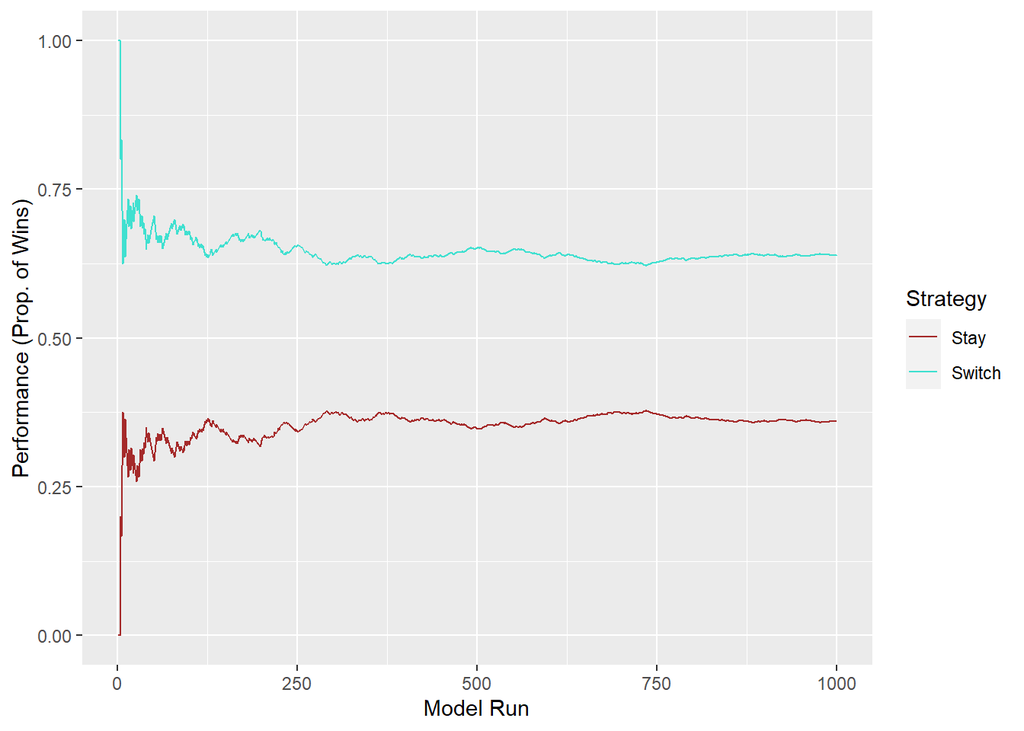

```r
#Convert cars to 1s and goats to 0s
results<-ifelse(results=="car",1,0)

#Create a dataframe to plot results
plotData<-data.frame("run"=1:modelLoops,
                     "strategy"=rep(c("Stay","Switch"),
                                    each=modelLoops),
                     "outcome"=c(cumsum(results[,1])/1:modelLoops,
                                 cumsum(results[,2])/1:modelLoops)
                     )

#Create a graph of the results
p1<-ggplot(data=plotData,
           aes(x=run,
               y=outcome,
               color=strategy))+
  labs(x="Model Run",
       y="Performance (Prop. of Wins)",
       color="Strategy")+
  geom_line()+
  scale_color_manual(values=c("brown","turquoise"))

p1
```